# Coursera Data Science Courses Projects Reproducible Research Week 2 Project

Andualem Bekele

January 19, 2018

## Loading and preprocessing the data

### Loadind the data file

```r
setwd("C:/Users/abekele/Documents/Corsera/Reproducible Research")
```

#### Looking at the five rows of the data - summary

```r
activitydata <- read.csv("activity.csv")
summary(activitydata)
```

```
##      steps                date          interval
##  Min.   :  0.00   2012-10-01:  288   Min.   :   0.0
##  1st Qu.:  0.00   2012-10-02:  288   1st Qu.: 588.8
##  Median :  0.00   2012-10-03:  288   Median :1177.5
##  Mean   : 37.38   2012-10-04:  288   Mean   :1177.5
##  3rd Qu.: 12.00   2012-10-05:  288   3rd Qu.:1766.2
##  Max.   :806.00   2012-10-06:  288   Max.   :2355.0
##  NA's   :2304     (Other)   :15840
```

```r
head(activitydata)
```

```
##   steps       date interval
## 1    NA 2012-10-01        0
## 2    NA 2012-10-01        5
## 3    NA 2012-10-01       10
## 4    NA 2012-10-01       15
## 5    NA 2012-10-01       20
## 6    NA 2012-10-01       25
```

## What is mean total number of steps taken per day?

### For this part of the assignmentthe missing values in the dataset are ignored.

### 1. Calculate the total number of steps taken per day

```r
steps <- aggregate(activitydata$steps, by = list(Date = activitydata$date), FUN = sum)
library(ggplot2)
names(steps)[names(steps) == "x"] <- "Total"
temp <- as.Date(steps$Date, "%Y-%m-%d")
steps$Date <- format(temp, format = "%m-%d")
head(steps)
```

```
##    Date Total
## 1 10-01    NA
## 2 10-02   126
## 3 10-03 11352
## 4 10-04 12116
## 5 10-05 13294
## 6 10-06 15420
```

### 2.Make a histogram of the total number of steps taken each day.

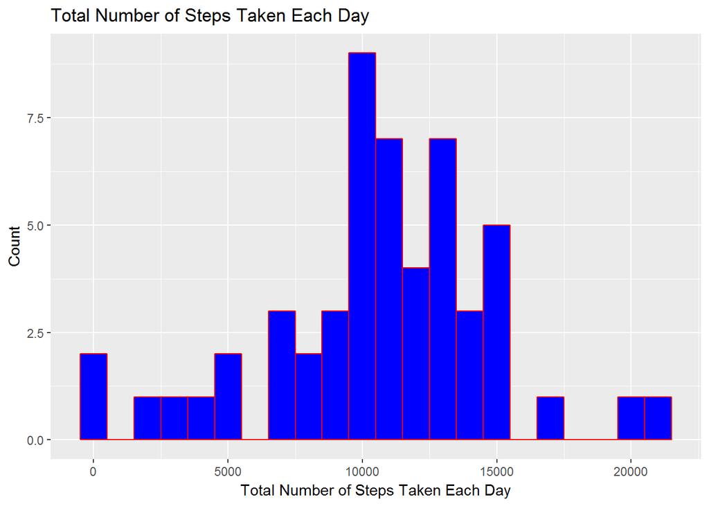

```r
hist1 <- ggplot(data = na.omit(steps), aes(Total)) +
    geom_histogram(binwidth = 1000, colour = "red", fill = "blue") +
    xlab("Total Number of Steps Taken Each Day") +
    ylab("Count") +
    ggtitle("Total Number of Steps Taken Each Day")
print(hist1)
```

### 3.Calculate and report the mean and median of the total number of steps taken per day

```r
mean(na.omit(steps$Total))
```

```
## [1] 10766.19
```

```r
median(na.omit(steps$Total))
```

```
## [1] 10765
```

### What is the average daily activity pattern?

### 4.Make a time series plot of 5-minute interval (x-axis) and the average number of steps taken, averaged across all days (y-axis)

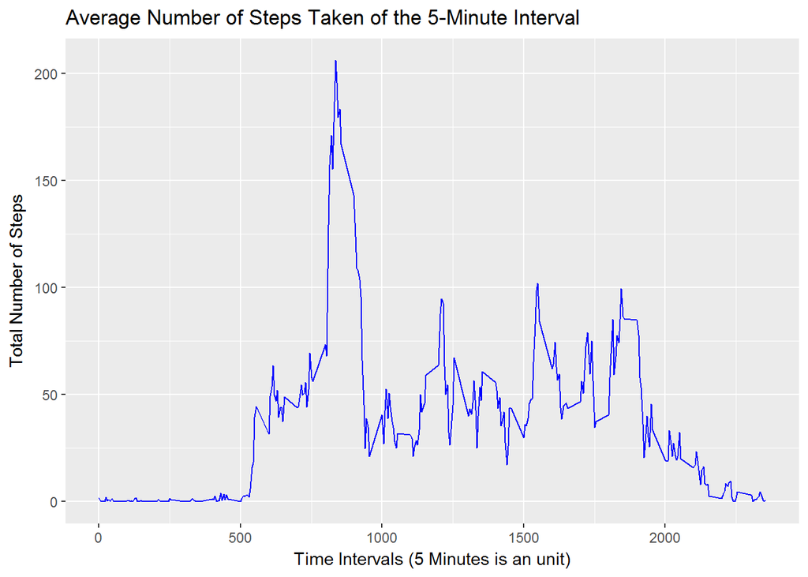

```r
five_min_steps <- aggregate(steps ~ interval, data = activitydata, FUN =mean)
TimeSeries1 <- ggplot(data = five_min_steps, aes(x = interval,  y = steps)) +
    geom_line(col = "blue") +
    xlab("Time Intervals (5 Minutes is an unit)") +
    ylab("Total Number of Steps") +
    ggtitle("Average Number of Steps Taken of the 5-Minute Interval")
print(TimeSeries1)
```

## Which 5-minute interval, on average across all the days in the dataset, contains the maximum number of steps?

Find the row with maximum number of steps and look at the 5 minute interval of that row

```r
head(five_min_steps)
```

```
##   interval     steps
## 1        0 1.7169811
## 2        5 0.3396226
## 3       10 0.1320755
## 4       15 0.1509434
## 5       20 0.0754717
## 6       25 2.0943396
```

```r
five_min_steps[which(five_min_steps$steps == max(five_min_steps$steps)),]
```

```
##     interval    steps
## 104      835 206.1698
```

## Replacing missing values

#### Calculate and report the total number of missing values in the dataset (i.e. the total number of rows with NAs)

```r
sapply(X = activitydata, FUN = function(x) sum(is.na(x)))
```

```
##    steps     date interval
##     2304        0        0
```

#### Devise a strategy for filling in all of the missing values in the dataset. The strategy does not need to be sophisticated. For example, you could use the mean/median for that day, or the mean for that 5-minute interval, etc. I will use the mean for that 5 -minute interval to replace all the missing values in the dataset. At the end, I will check if all the NAs have been replaced

```r
library(dplyr)
replacewithmean <- function(num) replace(num, is.na(num), mean(num, na.rm = TRUE))
meanofday <- (activitydata %>% group_by(interval) %>% mutate(steps = replacewithmean(steps)))
head(meanofday)
```

```
## # A tibble: 6 x 3
## # Groups:   interval [6]
##       steps       date interval
##       <dbl>     <fctr>    <int>
## 1 1.7169811 2012-10-01        0
## 2 0.3396226 2012-10-01        5
## 3 0.1320755 2012-10-01       10
## 4 0.1509434 2012-10-01       15
## 5 0.0754717 2012-10-01       20
## 6 2.0943396 2012-10-01       25
```

```r
sum(is.na(meanofday))
```

```
## [1] 0
```

### Create a new dataset with the missing data replaced with the mean.

```r
newdataset <- as.data.frame(meanofday)
head(newdataset)
```

```
##       steps       date interval
## 1 1.7169811 2012-10-01        0
## 2 0.3396226 2012-10-01        5
## 3 0.1320755 2012-10-01       10
## 4 0.1509434 2012-10-01       15
## 5 0.0754717 2012-10-01       20
## 6 2.0943396 2012-10-01       25
```

```r
summary(newdataset)
```

```
##      steps                date          interval
##  Min.   :  0.00   2012-10-01:  288   Min.   :   0.0
##  1st Qu.:  0.00   2012-10-02:  288   1st Qu.: 588.8
##  Median :  0.00   2012-10-03:  288   Median :1177.5
##  Mean   : 37.38   2012-10-04:  288   Mean   :1177.5
##  3rd Qu.: 27.00   2012-10-05:  288   3rd Qu.:1766.2
##  Max.   :806.00   2012-10-06:  288   Max.   :2355.0
##                   (Other)   :15840
```

#### Make a histogram of the total number of steps taken each day and Calculate and report the mean and median total number of steps taken per day. Do these values differ from the estimates from the first part of the assignment? What is the impact of imputing missing data on the estimates of the total daily number of steps? We make a histogram of the total number of steps taken each day first by using the new version dataset

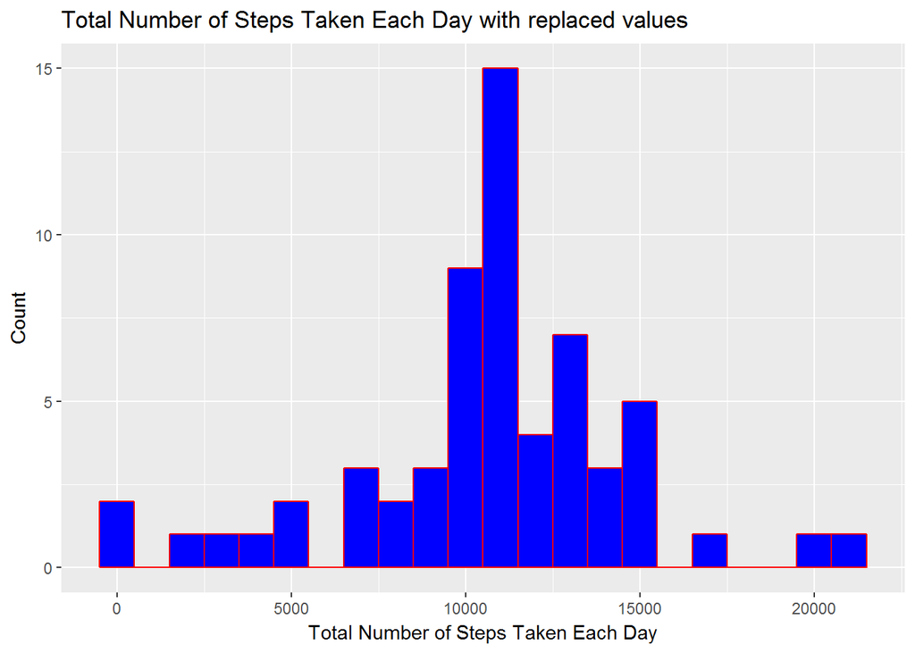

```r
new_steps <- aggregate(newdataset$steps, by = list(newdataset$date), FUN = sum)
names(new_steps)[names(new_steps) == "x"] <- "Total"
names(new_steps)[names(new_steps) == "Group.1"] <- "Date"
hist2 <- ggplot(data = new_steps, aes(Total)) +
  geom_histogram(binwidth = 1000, colour = "red" , fill = "blue")+
    xlab("Total Number of Steps Taken Each Day") +
    ylab("Count") +
    ggtitle("Total Number of Steps Taken Each Day with replaced values")
print(hist2)
```

compare the two plots

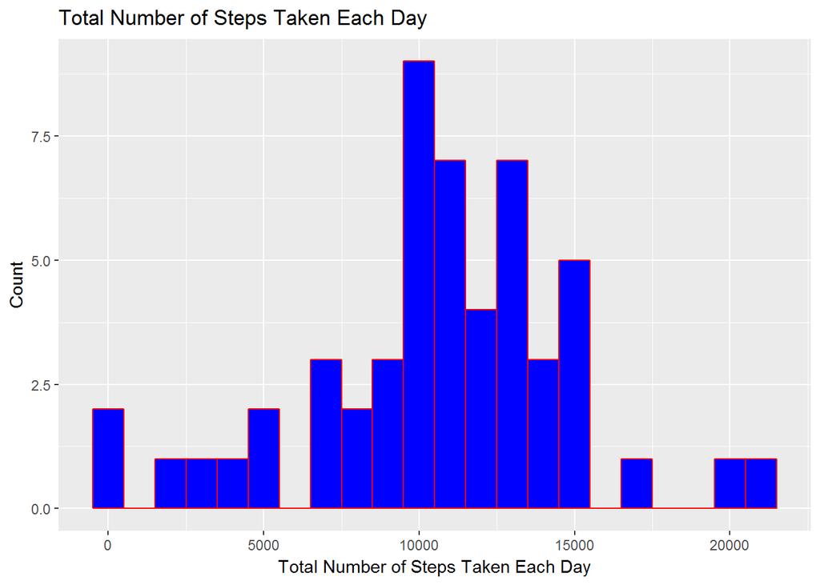

```r
print(hist1)
```

compare the two means

```r
mean(na.omit(steps$Total))
```

```
## [1] 10766.19
```

```r
median(na.omit(steps$Total))
```

```
## [1] 10765
```

```r
mean(new_steps$Total)
```

```
## [1] 10766.19
```

```r
median(new_steps$Total)
```

```
## [1] 10766.19
```

## Are there differences in activity patterns between weekdays and weekends?

Dataset with the replaced missing values is used

Create a new factor variable in the dataset with two levels - “weekday” and “weekend” indicating whether a given date is a weekday or weekend day.

```r
newdataset$WkendOrWkday <- ifelse(weekdays(as.Date(newdataset$date)) %in% c("Monday", "Tuesday", "Wednesday", "Thursday", "Friday"), "Weekday", "Weekend")
head(newdataset)
```

```
##       steps       date interval WkendOrWkday
## 1 1.7169811 2012-10-01        0      Weekday
## 2 0.3396226 2012-10-01        5      Weekday
## 3 0.1320755 2012-10-01       10      Weekday
## 4 0.1509434 2012-10-01       15      Weekday
## 5 0.0754717 2012-10-01       20      Weekday
## 6 2.0943396 2012-10-01       25      Weekday
```

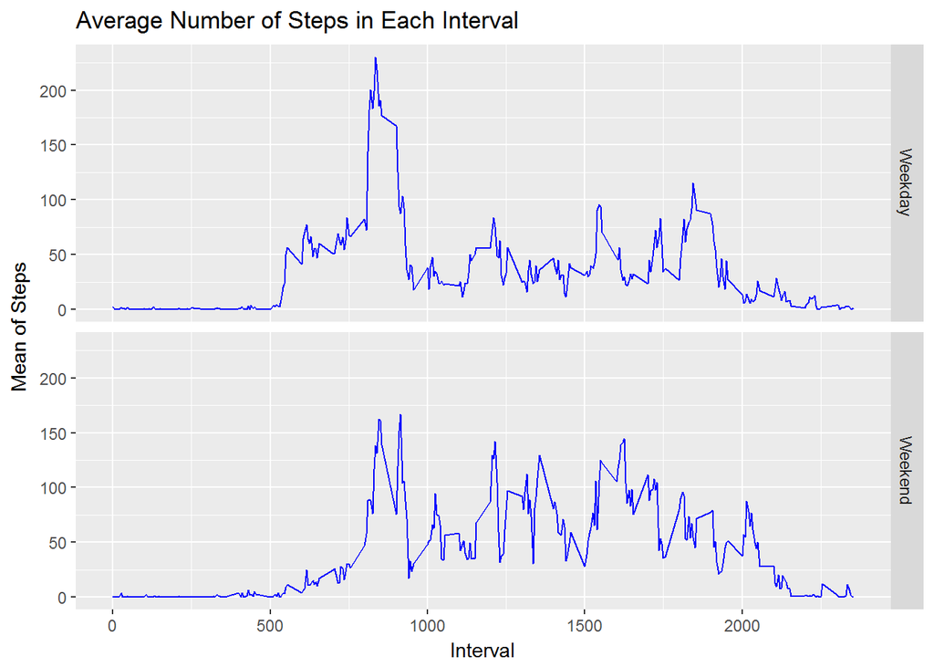

```r
newdataset <- (newdataset %>% group_by(interval, WkendOrWkday) %>% summarise(Mean = mean(steps)))
ggplot(newdataset, mapping = aes(x = interval, y = Mean)) + geom_line(col = "blue") +
    facet_grid(WkendOrWkday ~.) + xlab("Interval") + ylab("Mean of Steps") +
    ggtitle("Average Number of Steps in Each Interval")
```

Weekend activity patterns differ from weekdays paterns.